# Genetic code of bacteria

Alex Bajaña

6/5/2020

## Set up

In order to reproduce Gorban & Zinovyev paper about the use of PCA and K-Means to decipher genome first it’s necesary to get the genomic data of *Caulobacter Crescentus*. In this reproduction I will use R.

```r
install.packages("seqinr")
```

# Reading data

Read the Fasta file:

```r
sequence <- read.fasta("http://www.ihes.fr/~zinovyev/pcadg/ccrescentus.fa")
```

Now I will separate the genome in strings of length 300. In order to do that, first I create two functions:

# Creating frequency tables

```r
sep_vector <- function(vector,by){

  seq(by + 1,length(vector),by = by) %>%
    map(~{

      vector[(.x-by):(.x-1)]

    })

}
```

This functions takes a `vector` of charactes (all the genome), then `by` declares de length of the subset vectors saved in a list.

Now we have the genes in the list, as the goal of is to separte the genes in characters of lengt 1 to 4, I create another function which does:

- Separate the gene given a `length`
- Collapse the fragments
- Create a table with the frequency of each fragment
- Turn the table wide

All this operations, given a sequence subseted using `sep_vector`.

```r
subs_freq <- function(length, ...){
  sep_vector(...) %>%
    # map(length)
    map(~sep_vector(.x,length) %>%
          map(str_c,collapse = "") %>%
          unlist %>%
          table %>%
          enframe %>%
          spread(name,value)
    ) %>%
    reduce(bind_rows)
}
```

Then a table for each fragment legth is generated:

```r
string_separated <- map(1:4,subs_freq,vector = sequence$fragment,by = 300)
```

# PCA

The tables are saved in a list, in order to processing all in one sentence functional programming is used in combination with `tidyverse` framework.

```r
nested_pca <- string_separated %>%
  map(~.x %>%
        mutate_all(~replace_na(.,0)) %>%
        nest() %>%
        mutate(pca = map(data,~prcomp(.x,scale. = TRUE,center = TRUE)))

        )
```

First lets see some information about PCA for each table:

```r
performance <- nested_pca %>%
  map(~{
    .x$pca %>%
      map(~tidy(.x,"pcs")) %>%
      as.data.frame
  })
```

Let’s see the percentage of variance explained by each component:

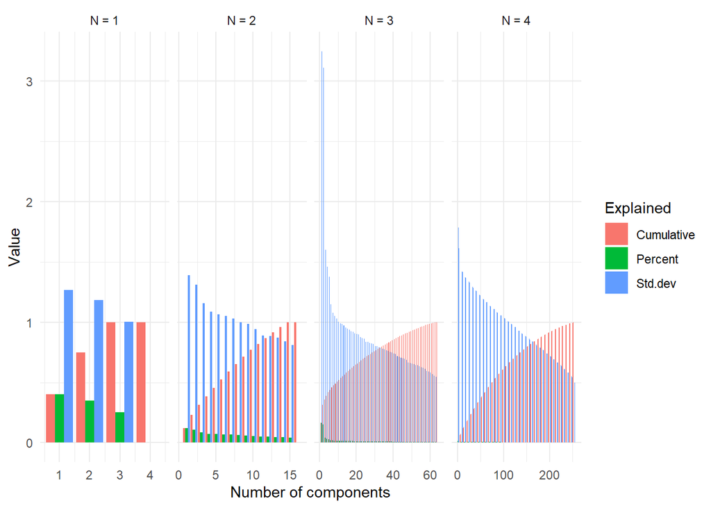

```r
map2(1:4,performance,~.y %>% mutate(length = str_c("N = ",.x))) %>%
  reduce(bind_rows) %>%
  gather("var","value",-PC,-length) %>%
  mutate(var = str_to_title(var)) %>%
  ggplot(aes(x = PC,y = value,fill = var)) +
  geom_bar(stat = "identity",position = "dodge") +
  facet_grid(.~length,scales = "free") +
  labs(x = "Number of components", y = "Value",fill = "Explained") +
  theme_minimal()
```

Extracting the components value:

```r
components <- nested_pca %>%
  map(~.x %>%

        mutate(pca_aug = map2(pca,data,~augment(.x,.y))) %>%
        unnest(pca_aug) %>%
        select(matches("PC"))
        )
```

Ploting between first and second component:

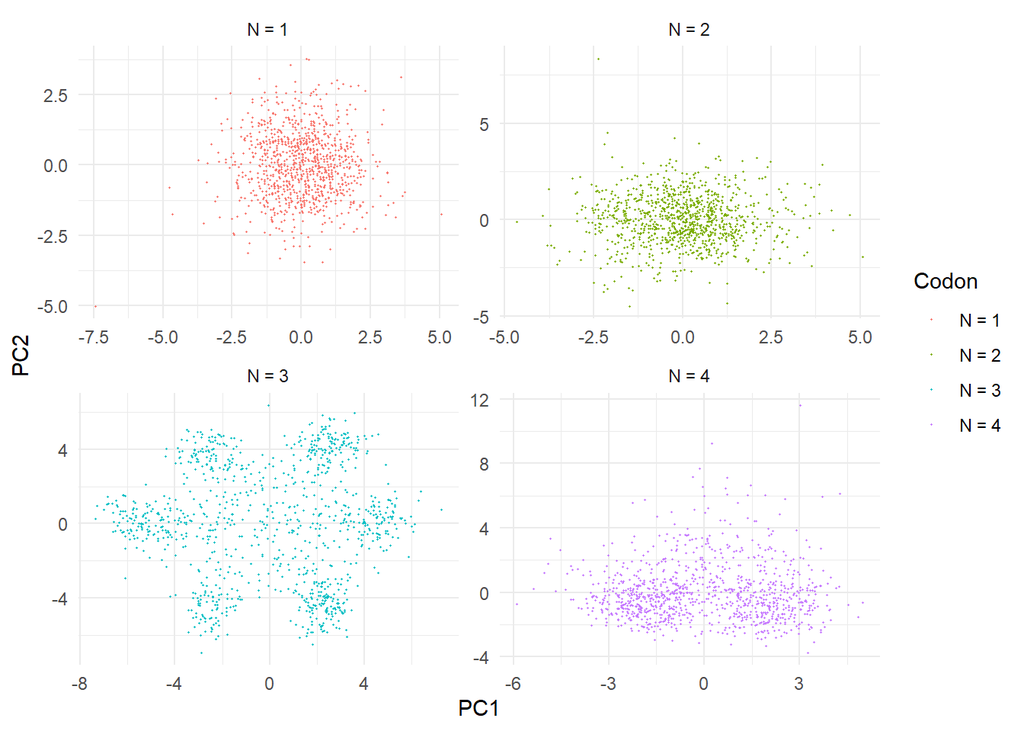

```r
map2(1:4,components,~.y %>% mutate(length = str_c("N = ",.x)) %>% select(length,.fittedPC1, .fittedPC2)) %>%
  reduce(bind_rows) %>%
  ggplot(aes(x =.fittedPC1,y = .fittedPC2, color = length )) +
  geom_point(size = 0.2)+
  facet_wrap(length~.,nrow = 2,ncol = 2,scales = "free") +
  labs(x = "PC1", y = "PC2", color = "Codon")+
  theme_minimal()
```

# Clustering

```r
clusters <- components[[3]] %>%
  select(2,3) %>%
  nest(data = everything()) %>%
  mutate(kmeans = map(data,~kmeans(.x,7)),
         points = map2(data,kmeans,~augment(.y,.x)) # En augment va primero kmeans, leugo data
         ) %>%
  unnest(points)
```

Visualize the clusters:

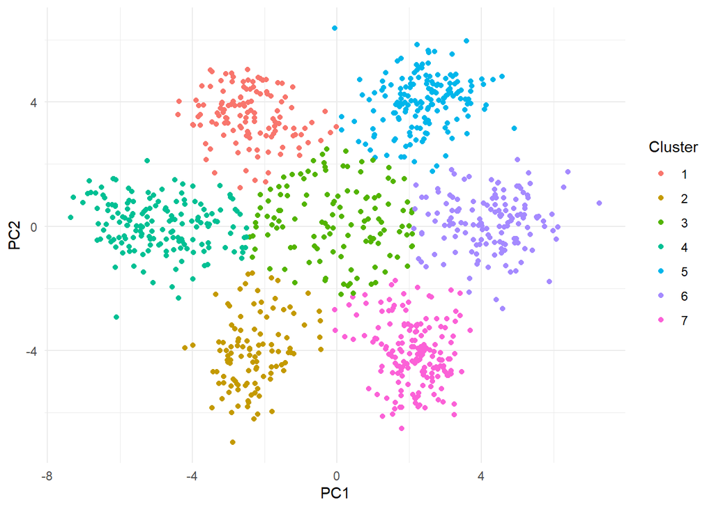

```r
clusters %>%
  ggplot(aes(x = .fittedPC1, y =.fittedPC2, color = factor(.cluster))) +
  geom_point() +
  labs(x = "PC1", y = "PC2", color = "Cluster") +
  theme_minimal()
```